# Writer Identification from Handwriting

STA5073Z Data Science for Industry: Assignment 2

UNIVERSITY OF CAPE TOWN  
Department of Statistical Sciences

STA5073Z Data Science for Industry  
Assignment 2: Image classification with neural networks

Writer Identification from Handwriting

| Group member | Student number | Main responsibilities |
| --- | --- | --- |
| Daniele Sguazzin | SGZDAN001 | Siamese network, Hyperparameter search, Results Comparison |
| Lucas Henze | HNZLUC002 | Data exploration, CNN, CNN hyperparameter search |

| Date | 16 October 2026 |
| --- | --- |
| GitHub repository | https://github.com/DanSguazzin17/STA5073Z-Assignment-2 |
| Report website | https://dansguazzin17.github.io/STA5073Z-Assignment-2/ |

# Declarations

## Plagiarism Declaration

We declare that this submission is our own work. Where ideas, material or assistance from other sources have been used, these have been acknowledged and referenced.

We understand that we are responsible for all material submitted, including material produced with the assistance of large language models. We have reviewed and checked the content of this submission and take responsibility for its accuracy and originality.

We have not knowingly presented the work of another person as our own.

| Name | Student number | Signature | Date |
| --- | --- | --- | --- |
| Daniele Sguazzin | SGZDAN001 | D. Sguazzin | 16 October 2026 |
| Lucas Henze | HNZLUC002 | L.Henze. | 16 October 2026 |

## AI Use Statement

Table 1: AI use by task.

[output not shown]

# 1 Introduction

In this report we study whether neural networks can learn handwriting differences from images of handwritten digits and identify the writer when presented with a new unseen digit.

The data set contains 25,000 simulated images of the digits 0 to 4, written by 20 people in five recording sessions. We address two questions. First, we train a convolutional neural network (CNN) to identify the writer of a single digit. Second, we train a Siamese network to decide whether two digits were written by the same person.

Our exploration shows that the handwriting of a writer changes considerably between sessions. We therefore develop all models on sessions 1 to 3, use session 4 for model selection and hyperparameter tuning, and keep session 5 as an unseen test set. The final models are retrained on sessions 1 to 4 and evaluated once on session 5. On this test session, the CNN identifies the correct writer in 73.3% of cases, compared to 5% by chance. The Siamese network decides correctly for 98.2% of test image pairs whether they come from the same writer, although this drops clearly when the two images come from different sessions.

The report is structured as follows. Section 2 describes the data and its sources of variation, and Section 3 explains our train, validation and test strategy. Section 4 and Section 5 present the two models, and Section 6 the hyperparameter tuning. Section 7 compares both approaches, and the last section concludes.

# 2 Data Exploration

## 2.1 Dataset structure

The data set consists of 25,000 grey-scale images of 28 × 28 pixels, with values between 0 (background) and 255 (ink). Each of the 20 writers wrote each of the digits 0 to 4 fifty times in each of five sessions, so every combination of writer, digit and session contains exactly 50 images. The design is fully balanced and there are no missing values. Before fitting any model, we scale the pixel values to [0, 1].

## 2.2 Variation between writers

A first look at the images already shows clear differences between writers (Figure 1). Some writers slant their digits to the right, others write upright. Writers also differ in the size of their digits and in how thick and dark their strokes are. To measure these differences, we computed eight simple features for every image: slant, height, width, the horizontal and vertical centre of the ink, the inked area, the total amount of ink and the mean stroke intensity. For each feature we then fitted a three-way ANOVA with digit, writer and session as factors. Because the design is balanced, the sums of squares split uniquely into the contributions of each factor and their interactions.

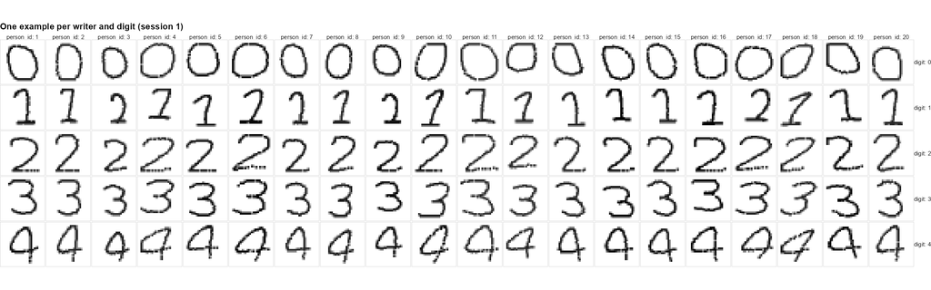

Figure 1: One example per writer and digit (session 1, first replicate).

Figure 2 shows the result, grouped into four sources. The style features are mainly driven by the writer: the writer explains 81% of the variance in slant, 72% in height and 60% in mean stroke intensity. Size and ink features, in contrast, mostly depend on which digit was written. For example, the digit explains 64% of the variance in inked area, so these features carry little information about the writer. The main effect of session is close to zero for all features (at most 0.9%). This means that there is no common change that affects all writers in the same way. The interactions between writer and session, however, are clearly present, especially for the position of the digit: terms involving session explain 40% of the variance in the vertical centre. Each writer therefore changes in their own way from one session to the next.

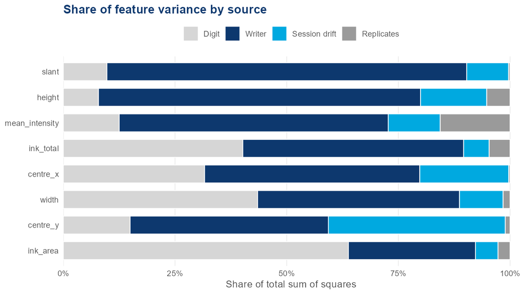

Figure 2: Share of the variance of eight image features by source, from a three-way ANOVA (digit × writer × session). “Writer” includes the writer × digit interaction; “Session drift” includes all terms involving session.

## 2.3 Variation across and within sessions

To check whether this drift also matters for the raw images, which are the input of our models, we decomposed the pixel variance within each digit into three parts: differences between writers, differences between sessions of the same writer, and differences between replicates within the same session (see the appendix for the equations). Figure 3 shows that 48–55% of the pixel variance lies between sessions of the same writer. This is more than the variance between writers (38–41%), and it holds for every digit. Replicates within one session explain only 6–12%. Figure 4 illustrates this: the mean image of the same writer can look quite different in different sessions. In other words, the same writer on a different day can differ more than two different writers. A new session is therefore the hard case for writer identification, and this is the main reason for our split strategy in Section 3.

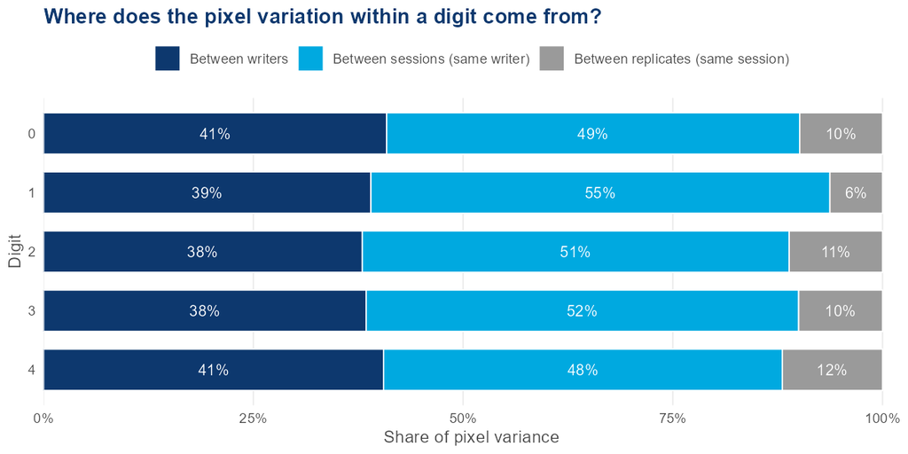

Figure 3: Decomposition of pixel variance within each digit into between-writer, between-session (same writer) and between-replicate (same session) parts.

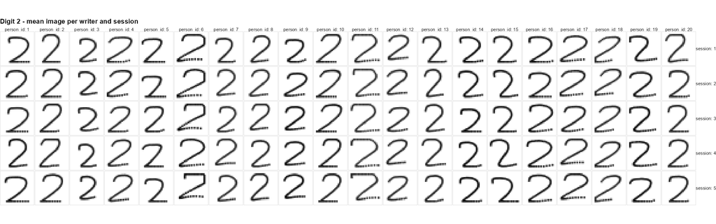

Figure 4: Mean image of digit 2 per writer and session.

## 2.4 Limitations of the simulated data

The data are simulated, and several properties show this. The ink values fall into four separated bands with clear gaps between them, plus a spike at the maximum value of 255 (Figure 5). Real scans would show a smooth range of grey levels, because ink density varies continuously along and across a stroke. Some strokes are dashed, which does not happen with a pen, and the digit 1 leaves little room for individual style. The replicates within a session are almost identical copies of each other. Effectively, each writer and digit is therefore represented by five independent observations, one per session, rather than by 250 images. Finally, a model could learn properties of the simulator rather than of real handwriting, so our results are likely to be optimistic for real data.

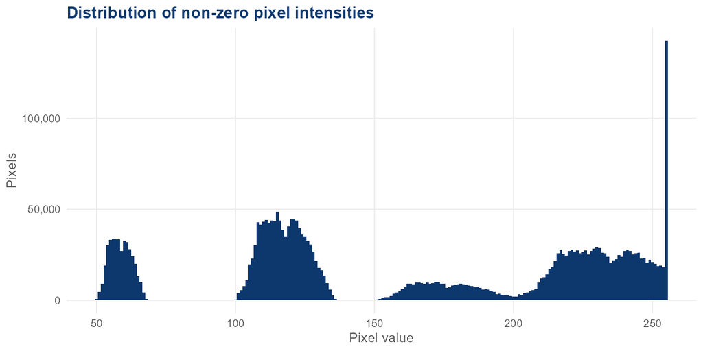

Figure 5: Distribution of non-zero pixel intensities over all images.

# 3 Train, Validation and Test Strategy

## 3.1 Chosen split

Our split follows directly from the exploration. Since the hardest case is recognising a known writer in a new session, we split the data by session rather than by image. Sessions 1 to 3 are used for training, session 4 for validation and session 5 as the test set. Each set contains all 20 writers and all five digits, so the only thing that is new in the validation and test sets is the recording session. We use the same split for the Siamese network.

## 3.2 What kind of generalisation this represents

The validation session is used for all decisions during development: early stopping, model selection and hyperparameter tuning. After these decisions were made, we retrained the final models on sessions 1 to 4 and evaluated it once on session 5. The test session was not used for any decision, so the test accuracy is an unbiased estimate of how well the model identifies known writers on a new day. This defines what kind of generalisation our evaluation represents. It measures closed-set identification: all writers are known from training, but their handwriting comes from a new session. It does not measure how well the model works for new writers. A CNN with 20 output classes cannot recognise a person who was not in the training data. The same applies to the Siamese network, whose test pairs come from the same 20 writers.

## 3.3 Leakage and optimistic performance

The common (and simpler approach) would be to split the images at random. This, however, creates a leakage problem, that arises from the fact that images within sessions are nearly-identical. Therefore a random split puts those almost-replicates into both the training and the test set. Hence, the model only has to recognise images it has almost seen before. Table 2 shows the effect for the baseline CNN: with a random split, the test accuracy is 99.9%, compared to 61.3% with the session split. A random split would therefore greatly overstate how well the model would actually work in practice.

Table 2: Test accuracy of the baseline CNN by digit under a session split and a random image-level split (one seed).

| Digit | Session split | Random split | Gap |
| --- | --- | --- | --- |
| 0 | 56.7% | 100.0% | 43.3 pp |
| 1 | 65.0% | 100.0% | 35.0 pp |
| 2 | 58.2% | 100.0% | 41.8 pp |
| 3 | 56.0% | 99.8% | 43.8 pp |
| 4 | 70.6% | 99.7% | 29.1 pp |

## 3.4 Random seeds

Furthermore, as the training process involves randomness i.e. within the starting weights, the order in which the images are shown, dropout and the random shifts all differ from one run to the next. Fixing the random seed makes these choices, and therefore the whole training run, reproducible. Changing the seed, on the other hand, leads to a slightly different model. For this reason, we trained every CNN configuration with several seeds, three during tuning and five for the final model, and compared their mean accuracies to have a more robust result.

# 4 CNN for Writer Identification

## 4.1 Prediction task and model

We define writer identification as a classification problem with 20 classes. The input is a single 28 × 28 image, and the response is the writer ID. The network outputs a probability for each of the 20 writers through a softmax layer and is trained by minimising the cross-entropy loss. A model that guesses at random would be correct in 5% of cases.

Table 3 shows the architecture. We use a small CNN with three convolutional blocks. Each block applies 3 × 3 filters with a ReLU activation, followed by 2 × 2 max pooling, which halves the resolution. The number of filters grows from 16 to 32 to 64, so that later blocks can combine simple stroke patterns into more complex shapes (LeCun et al. 1998). A dense layer with 64 units and a dropout rate of 0.5 (Srivastava et al. 2014) then combines these features, and the final softmax layer assigns probabilities to the writers. The model has 61,524 parameters in total. We kept the network small on purpose: the images are small, the models had to train on a laptop CPU, and the exploration showed that the number of independent observations is low.

Table 3: CNN architecture. Output shape as height × width × channels; dropout and random shifts have no parameters.

| Layer | Output | Parameters |
| --- | --- | --- |
| Input | 28 × 28 × 1 | 0 |
| Random shift (± 10%, training) | 28 × 28 × 1 | 0 |
| Conv 3 × 3, 16 filters + max pool | 14 × 14 × 16 | 160 |
| Conv 3 × 3, 32 filters + max pool | 7 × 7 × 32 | 4,640 |
| Conv 3 × 3, 64 filters + max pool | 3 × 3 × 64 | 18,496 |
| Flatten | 576 | 0 |
| Dense 64, ReLU + dropout 0.5 | 64 | 36,928 |
| Dense 20, softmax | 20 | 1,300 |

During training, each image is randomly shifted by up to 10% of its width and height. This augmentation imitates the changes in position between sessions that we found in the exploration, and its benefit is shown in Section 6. The shifts are only applied during training, not at prediction time.

## 4.2 Training

We trained the network with the Adam optimiser (Kingma and Ba 2015), a learning rate of 10⁻³ and a batch size of 64, using the keras3 package in R (Kalinowski et al., n.d.). During development we used early stopping on the validation session with a patience of five epochs and restored the weights of the best epoch. We monitored validation accuracy rather than validation loss. On a new session the validation loss starts to rise very early, at epoch 1 with the default learning rate, because the model becomes over-confident in its wrong predictions. Validation accuracy, however, still improves for several epochs. Stopping on the loss would therefore end training too early.

For the final model, we retrained the chosen configuration on sessions 1 to 4. As no validation session is left for early stopping, we trained for a fixed number of 14 epochs, the median best epoch of this configuration during tuning. To show how much the results depend on the random initialisation, we repeated the training with five different seeds and report the mean and standard deviation. Session 5 was used only once, for this final evaluation.

## 4.3 Results

The final CNN identifies the correct writer in 73.3% ± 1.8 pp of the test images (Table 4). In 91.7% of cases the correct writer is among the three most likely writers. The same configuration trained only on sessions 1 to 3 reaches 67.3%. One additional recording session per writer thus improves accuracy by 5.9 pp, which shows that seeing more of a writer’s variation helps considerably.

Table 4: Test accuracy of the final CNN on session 5, mean ± sd over five seeds.

| Trained on | Accuracy | Top-3 accuracy |
| --- | --- | --- |
| sessions 1-4 | 73.3% ± 1.8 pp | 91.7% ± 2.2 pp |
| sessions 1-3 | 67.3% ± 3.0 pp | 90.9% ± 1.8 pp |

Accuracy is very similar for all digits, between 72–75% (Figure 6). The standard deviations across seeds are between 2.7–4.1 pp, so the differences between digits are within the training noise. For the CNN, none of the digits carries clearly more writer information than the others.

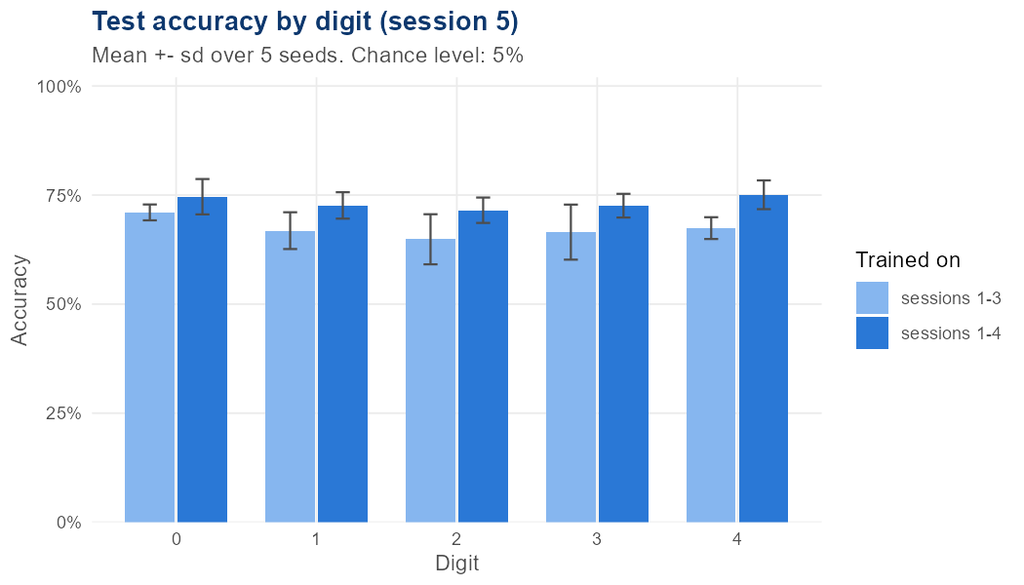

Figure 6: Test accuracy by digit (session 5), mean ± sd over five seeds, for the final model trained on sessions 1–4 and the same configuration trained on sessions 1–3.

The average hides large differences between writers (Figure 7). 11 of the 20 writers are recognised in at least 90% of cases. At the other end, writer 5 is almost never recognised (0.2%), and the correct writer is rarely even among the top three (1.1%). For other weak writers, such as writers 1, 8, and 10, top-1 accuracy is low (24–45%), but top-3 accuracy is high (93–100%). These writers are confused with a few similar writers rather than being unrecognisable (see the confusion matrix in Figure 14).

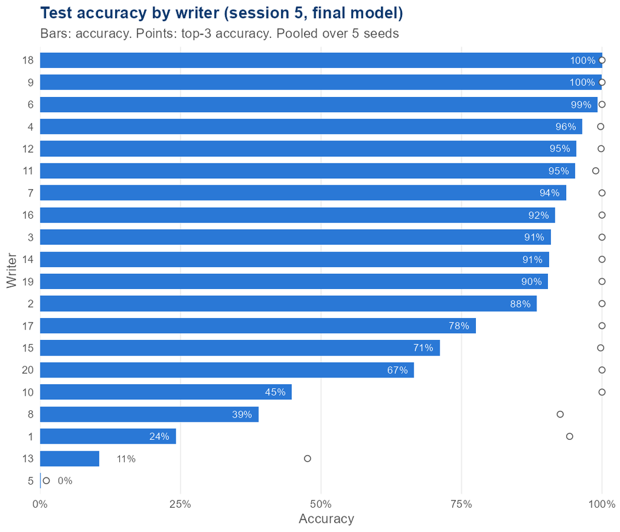

Figure 7: Test accuracy (bars) and top-3 accuracy (points) by writer, pooled over five seeds.

In practice, a document usually contains more than one digit. We therefore combined the predictions for k randomly drawn test images of the same writer by summing their log-probabilities. Figure 8 shows that this raises accuracy only from 73.1% with one image to 77.1% with 25 images. If the errors were random from image to image, combining images would quickly remove them. The small gain shows that the errors are systematic: when the model fails for a writer in session 5, it fails for most of that writer’s images. This is consistent with the writer-specific drift found in Section 2.

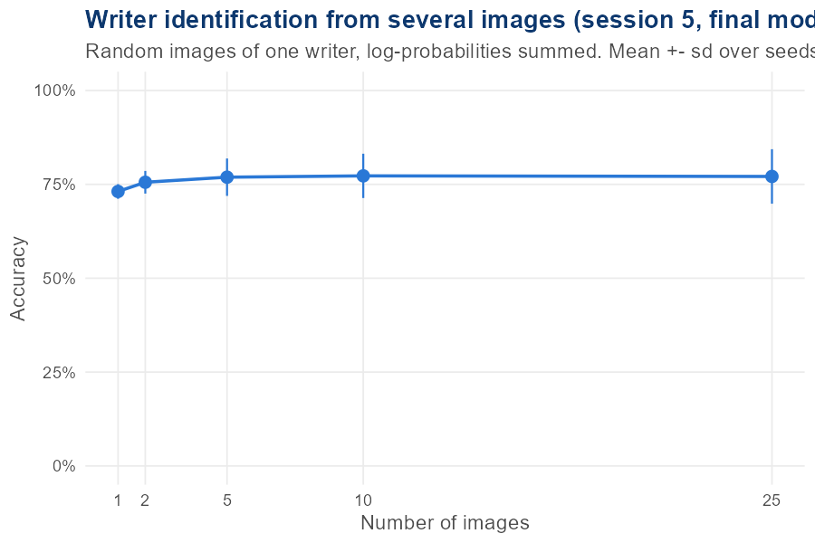

Figure 8: Accuracy when the log-probabilities of k random session-5 images of the same writer are summed, mean ± sd over five seeds.

## 4.4 What the evaluation measures mean in practice

Accuracy is the probability that a single digit is assigned to the right person. At 73% this is far above chance, but not reliable enough for an automatic decision about who wrote a digit. Top-3 accuracy describes a different use case: the model proposes a short list of three candidates, which a human examiner then checks. For this purpose the model is much more useful, as the true writer is on the list in 92% of cases. The results per writer add an important caveat. The average hides writers who are almost never recognised, so in practice the model would be reliable for some people and fail for others. Finally, all results refer to a closed set of 20 known writers. A person who was not in the training data cannot be identified by this model at all.

# 5 Siamese Network for Same-Writer Matching

## 5.1 Architecture and contrastive loss

A Siamese network asks a different question than the CNN. Instead of naming which of the 20 writers wrote an image, it looks at two images and decides if the same person wrote both. Both images pass through the same small convolutional network, called the encoder, using the same weights for each image, which is why the model is called “Siamese”, or twin (Table 5). The encoder works like this: a convolutional layer (16 filters) with max pooling, a second convolutional layer (32 filters), then global average pooling, then a dense layer that outputs an *embedding*: a short list of numbers summing up the handwriting style of one image. The two embeddings are then compared using Euclidean distance, the model’s only output. A small distance should mean “same writer”, a large distance “different writer”.

Table 5: Siamese network encoder architecture, applied identically to both images in a pair, so parameters are shared rather than doubled. Output shape as height × width × channels, or units for the embedding.

| Layer | Output | Parameters |
| --- | --- | --- |
| Input | 28 × 28 × 1 | 0 |
| Conv 3 × 3, 16 filters + max pool | 13 × 13 × 16 | 160 |
| Conv 3 × 3, 32 filters | 11 × 11 × 32 | 4,640 |
| Global average pooling | 32 | 0 |
| Dense 16 (embedding) | 16 | 528 |

The encoder has 5,328 parameters in total, shared by both images in a pair rather than doubled, which keeps the model small and fast to train.

The model is trained with contrastive loss. For a same-writer pair, the loss punishes the model if the two embeddings are far apart. For a different-writer pair, it only punishes embeddings that are closer than a set margin: once two different writers’ embeddings are far enough apart, there is no extra reward for pushing them further. The embedding size and margin are both hyperparameters. The final model uses an embedding size of 16 and a margin of 0.5, picked by the search described in Section 6.

## 5.2 Constructing training pairs

Each training pair starts with one image, and a coin flip decides if the second image should come from the same writer or a different one, giving a roughly even 50/50 split. Both images in a pair always show the same digit. This matters because without it, the network could just learn to spot which digit is in each image instead of who wrote it, since digit shape is a much easier shortcut than handwriting style. Matching on digit forces the network to rely on style clues instead, such as slant and stroke thickness, which carry over even when the digit changes. An image is also never paired with itself.

Pairs are only built within one data split, so no image appears in more than one of training, validation or test. The project uses one session split throughout: sessions 1-3 for training, session 4 for validation, and session 5 for test (see Section 3). Table 6 shows how many pairs were built for each stage.

Table 6: Number of pairs built for each stage of the Siamese network, and the sessions each stage drew from.

| Stage | Sessions | Pairs |
| --- | --- | --- |
| Hyperparameter search (train) | 1-3 | 8,000 |
| Validation | 4 | 2,000 |
| Test | 5 | 2,000 |
| Final model (train) | 1-4 | 10,000 |

The hyperparameter search, validation and test pairs all come from the same sessions 1-3/4/5 split used throughout the report. Once the best hyperparameters were chosen using validation only, the final model was retrained on a fresh, larger set of pairs drawn from sessions 1-4 combined, then tested once on the untouched test pairs.

## 5.3 From distance to a same-writer decision

The model only outputs a distance, not a simple yes or no, so a threshold is needed to turn a distance into “same writer” or “different writer”. Many candidate thresholds were tried on the validation pairs, and the one with the best *balanced accuracy* was kept. The *balanced accuracy* is the average of how often same-writer pairs are correctly caught and how often different-writer pairs are correctly caught. Balanced accuracy was used instead of plain accuracy so the model cannot score well just by leaning toward one answer. The final threshold (0.156) was locked in using validation data only, then reused as is on the test pairs, so no test information affected the decision rule.

## 5.4 Matching performance

The final Siamese network was tested on 2,000 held-out pairs from session 5, which it never saw during training or tuning. It reaches 98.2% balanced accuracy meaning it correctly spots same-writer pairs 98.9% of the time and different-writer pairs 97.4% of the time (Table 7). In simple terms, given two handwriting samples, the model correctly says whether they are from the same person about 98% of the time, in a session it has never seen before.

Table 7: Siamese network balanced accuracy by data split, using the distance threshold locked in on the validation set (0.156).

| Split | Balanced accuracy |
| --- | --- |
| Train (sessions 1-4) | 77.4% |
| Validation (session 4) | 98.0% |
| Test (session 5) | 98.2% |

Figure 9 shows why this works: distances for same-writer pairs cluster near zero, distances for different-writer pairs are spread out and mostly sit well above the threshold, and the overlap between the two groups is small.

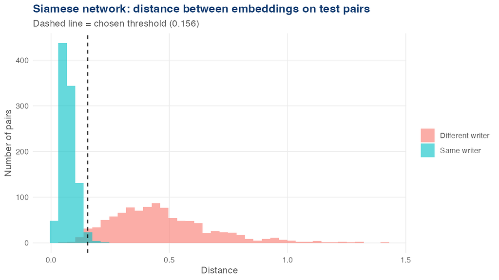

Figure 9: Distances between embeddings for same-writer and different-writer test pairs (session 5). The dashed line is the threshold (0.156) chosen on the validation set.

## 5.5 Does test accuracy overstate cross-session performance?

The train balanced accuracy is 77.4%. This is lower than both validation and test, which looks strange at first. Splitting the result by pair type shows why, and it changes how we should read the headline number. On training pairs, same-writer detection is only 57.2%. This is far below different-writer detection, which sits at 97.6%. On test, the two numbers are close together, at 98.9% and 97.4%. The reason is session structure, not a weaker model. Test pairs only come from session 5. This means same-writer test pairs are always two images from one sitting, where handwriting stays most consistent. Training same-writer pairs are different. They are drawn from sessions 1-4 and often pair two sittings from the same writer, and handwriting drifts a bit between sessions. This makes the training pairs a genuinely harder problem. The model has learned to spot a writer well within one sitting, but the test set never checks the harder, more realistic case of matching handwriting across different sittings. So the 98.2% test balanced accuracy is best read as a measure of within-session matching, not cross-session matching.

## 5.6 Quick exploration: matching across two unseen sessions

Table 8: Within-session test (session 5 only) compared with the forced cross-session test (session 4 paired with session 5), using the same model and threshold.

| Test type | Balanced accuracy | Same-writer rate | Different-writer rate |
| --- | --- | --- | --- |
| Within-session (normal test) | 98.2% | 98.9% | 97.4% |
| Cross-session (forced session 4 vs. 5) | 66.6% | 36.7% | 96.5% |

The drop is large, and it sits entirely on the same-writer side. Different-writer pairs are still caught almost as well across sessions, at 96.5%, as within one session, at 97.4%. This is because two different people’s handwriting usually looks different no matter which session the images come from. Same-writer pairs are a different story. The rate falls from 98.9% to 36.7%. This happens because one person’s own handwriting drifts between sessions more than expected, so the model often fails to recognise it is the same person. This is session drift, the same effect discussed above for the training pairs. It is a good illustration of why the 98.2% headline test accuracy measures within-session matching, not the harder, more realistic case of matching across sessions.

# 6 Hyperparameter Optimisation

The brief only asks for a hyperparameter search on one of the two models. In practice both models were tuned, so both are reported here, each in its own short section below.

## 6.1 CNN hyperparameter search

The tuning was done in the following steps:

1. **Baseline.** We started from the CNN in Section 4 without augmentation: filters 16-32-64, dropout 0.5 and no shift.
2. **One hyperparameter at a time.** We changed one hyperparameter and kept the others at their baseline values. We tried shifts of 0.05, 0.1 and 0.15, dropout rates of 0.25 and 0.7, and filters of 8-16-32 and 32-64-128.
3. **Training and evaluation.** Each configuration was trained on sessions 1 to 3 with three different seeds. We used early stopping on the validation accuracy (session 4) with a maximum of 50 epochs, and recorded the validation accuracy and the best epoch of each run. Configurations were compared by their mean validation accuracy over the three seeds.
4. **Combination.** We planned to combine the best values of all hyperparameters that improved on the baseline by more than the seed-to-seed variation. Only the shift did, so no combined configuration was needed.
5. **Depth.** On top of the best configuration so far, we tried two and four convolutional blocks instead of three. More than four blocks is not possible, as each pooling step halves the resolution (28 → 14 → 7 → 3 → 1).

We chose this one-at-a-time design instead of a full grid search for two reasons. A full grid over the values in step 2 alone has 36 configurations, or 108 training runs with three seeds, compared to the 10 configurations we trained. In addition, the seed alone changes the validation accuracy by about 1.7 pp, so many configurations in a fine grid would not be distinguishable from each other.

Figure 10 and Table 9 show the results. The random shift is the only hyperparameter with a clear effect. A shift of 0.1 raises the validation accuracy from 60.2% to 64.8% (+4.6 pp), while shifts of 0.05 (62.8%) and 0.15 (63.4%) help less. Dropout hardly matters (58.7% with 0.25 and 59.8% with 0.7). More filters make the model worse (56.0%), which fits the picture of a model that already memorises the training sessions. Two blocks reach 63.6%. Four blocks give the highest mean value (66.1%), but a closer look at the validation curve showed that this rests on a single spike at epoch 3 (65.8%, followed by 57.5%) and a plateau of about 63% afterwards. Early stopping simply picked a lucky epoch, so we did not use this configuration.

Overall, the evaluation is not very sensitive to most of the hyperparameters we varied: the changes from dropout stay within the seed noise, and more capacity only makes the model worse. The one setting that matters is the augmentation, which is consistent with the session drift found in Section 2. For the final model we therefore kept three blocks with filters 16-32-64 and dropout 0.5, and added a shift of 0.1. Its median best epoch during tuning (14) fixed the number of epochs for the final training on sessions 1 to 4.

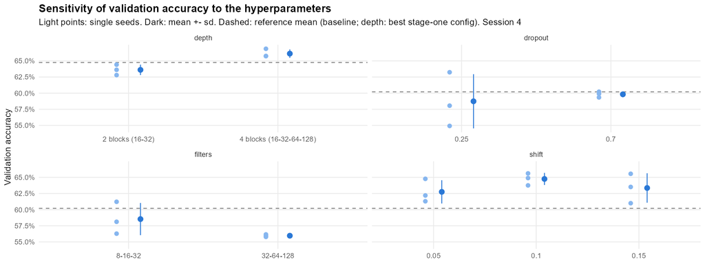

Figure 10: Validation accuracy (session 4) for each hyperparameter setting. Light points: single seeds; dark points: mean ± sd; dashed line: reference configuration.

Table 9: Validation accuracy (session 4) of all configurations, mean and sd over three seeds, with the median epoch chosen by early stopping.

| Hyperparameter | Value | Accuracy | SD | Top-3 | Best epoch |
| --- | --- | --- | --- | --- | --- |
| depth | 4 blocks (16-32-64-128) | 66.1% | 0.7 pp | 83.6% | 3 |
| shift | 0.1 | 64.8% | 0.9 pp | 82.5% | 14 |
| depth | 2 blocks (16-32) | 63.6% | 0.8 pp | 84.4% | 8 |
| shift | 0.15 | 63.4% | 2.3 pp | 82.7% | 16 |
| shift | 0.05 | 62.8% | 1.8 pp | 86.4% | 7 |
| baseline | baseline | 60.2% | 3.1 pp | 84.9% | 12 |
| dropout | 0.7 | 59.8% | 0.4 pp | 85.7% | 3 |
| dropout | 0.25 | 58.7% | 4.2 pp | 82.7% | 2 |
| filters | 8-16-32 | 58.5% | 2.5 pp | 85.0% | 7 |
| filters | 32-64-128 | 56.0% | 0.2 pp | 84.3% | 5 |

## 6.2 Siamese network hyperparameter search

The search varied one hyperparameter at a time around a baseline setting, and kept everything else fixed. We varied two things, the embedding size (8, 16 or 32) and the margin used in the contrastive loss (0.5, 1 or 2). Each setting was trained on sessions 1-3 and scored on validation (session 4) balanced accuracy, since this choice has to stay separate from the untouched test set.

Table 10 and Figure 11 show the result.

Table 10: Validation balanced accuracy of the Siamese network for each hyperparameter setting. Only one value changes from the baseline in each row.

| Setting | Embedding size | Margin | Balanced accuracy |
| --- | --- | --- | --- |
| Baseline | 16 | 1.0 | 97.0% |
| Smaller embedding | 8 | 1.0 | 97.1% |
| Larger embedding | 32 | 1.0 | 97.5% |
| Smaller margin | 16 | 0.5 | 98.0% |
| Larger margin | 16 | 2.0 | 96.0% |

All five settings land close together, between 96% and 98% balanced accuracy. The embedding size made almost no difference on its own. Sizes 8, 16 and 32 all score within about half a point of each other. The margin mattered a bit more. The smaller margin (0.5) scored best, and the larger margin (2) scored worst. The gap between them is about two points.

Since the smaller margin setting scored highest on validation, it was chosen for the final model. This means an embedding size of 16 and a margin of 0.5, the same values used throughout the earlier results in this report. The differences between settings are small, so this is not a strong win. It is still the best option found, though, and the model does not seem to depend heavily on getting this exact choice right. Each setting here was trained once rather than over several seeds, unlike the CNN search, so these small differences may partly reflect run-to-run variation rather than a true effect.

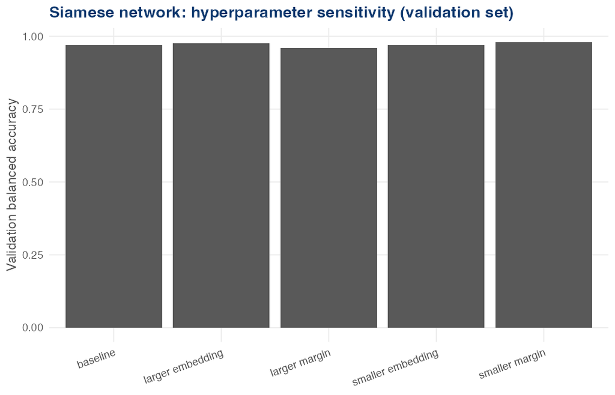

Figure 11: Validation balanced accuracy of the Siamese network for each hyperparameter setting.

# 7 Comparing the CNN and Siamese Network

## 7.1 Comparing performance

The CNN and the Siamese network answer different questions, so their accuracy numbers cannot be compared directly as raw percentages. The CNN picks one writer out of 20 known writers for a single image, so a random guess would be right about 5% of the time. The Siamese network only decides if two images were written by the same person or not, so a random guess would be right about 50% of the time, like a coin flip. Because the two models start from such different chance levels, a fairer comparison looks at how far each model gets above its own chance level, not just at the final score (Table 11).

Table 11: CNN and Siamese network performance on session 5, each measured against its own chance level.

| Model | Task | Chance level | Test score | Above chance |
| --- | --- | --- | --- | --- |
| CNN | Name which of 20 writers wrote the image | 5% | 73.3% accuracy | 68.3 pp |
| Siamese network | Decide if two images are from the same writer | 50% | 98.2% balanced accuracy | 48.2 pp |

On the raw numbers, the Siamese network looks better: 73.3% for the CNN against 98.2% for the Siamese network. But once chance level is taken into account, the picture is less one-sided. The CNN’s score is about 68.3 pp above its own chance level of 5%, while the Siamese network’s score is about 48.2 pp above its own chance level of 50%. So the CNN is actually further above chance than the Siamese network is, even though its raw accuracy number is lower. This is why the two headline numbers should not be read side by side on their own: a harder task with a low chance level, like naming one writer out of 20, can look worse on paper than an easier task with a high chance level, like a same-or-different decision, even when the model on the harder task is doing comparatively more work.

There is also a practical difference between the two models that the numbers alone do not show. The CNN can only recognise the 20 writers it was trained on. A new person who was not in the training data cannot be identified at all, and adding them would mean retraining the model from scratch. The Siamese network does not need to know who a person is, only whether two images look like they came from the same person, so in principle it could compare handwriting from someone outside the original 20 writers without retraining. This project does not test that case directly, since every image used here comes from the same 20 writers, but it is a meaningful practical advantage of the Siamese approach for a system that might need to handle new people later.

## 7.2 Which digits carry the most writer information

The CNN’s per-digit accuracy is already shown in Section 4 (Figure 6). To compare this with the Siamese network, we built a fresh set of same-digit test pairs for each digit on its own, then scored the already-trained Siamese model on each set using the usual locked-in threshold. Table 12 puts the two side by side.

Table 12: CNN test accuracy and Siamese network balanced accuracy by digit, both on session 5.

| Digit | CNN accuracy | Siamese balanced accuracy |
| --- | --- | --- |
| 0 | 74.6% | 99.5% |
| 1 | 72.6% | 97.2% |
| 2 | 71.5% | 97.5% |
| 3 | 72.6% | 97.1% |
| 4 | 75.1% | 99.0% |

Both models tell the same story: no digit stands out as clearly easier or harder. For the CNN, accuracy is between 72–75% across all five digits, and this small spread is within the normal seed-to-seed noise (Section 4). For the Siamese network, balanced accuracy is between 97.1% and 99.5%, a similarly small spread, although this check only used one run rather than several seeds, so part of this spread may also just be noise rather than a real digit effect.

This agreement makes sense given what the data exploration found in Section 2. The features that separate writers, such as slant and stroke thickness, come from a person’s handwriting style and show up in the same way regardless of which digit is drawn. Since neither model has a particular digit to rely on for extra writer information, it is expected that performance stays roughly flat across digits for both of them.

## 7.3 How session changes affect performance

Both models are affected by the same underlying problem: a person’s handwriting is not perfectly stable from one recording session to the next, which we first saw in Section 2. Table 13 pulls together how each model is affected by this.

Table 13: How each model’s performance on session 5 changes with the amount or type of session information used.

| Model | Comparison | Lower result | Higher result | Difference |
| --- | --- | --- | --- | --- |
| CNN | Trained on sessions 1-3 vs. sessions 1-4 (one extra training session) | 67.3% (sessions 1-3) | 73.3% (sessions 1-4) | 5.9 pp |
| Siamese network | Tested within one session vs. across two unseen sessions | 66.6% (across sessions 4 and 5) | 98.2% (within session 5) | 31.6 pp |

The two rows are not testing exactly the same thing. For the CNN, we changed how much training data the model saw, by adding one extra recording session, and both numbers come from testing on session 5. For the Siamese network, we kept the same model and instead changed what kind of pairs it was tested on: pairs from one session, or pairs forced across two different, unseen sessions. Even so, both rows point to the same conclusion. Giving the CNN one more training session, which lets it see more of each writer’s session-to-session variation, raises its accuracy by 5.9 pp. Testing the Siamese network across sessions it has never combined before drops its balanced accuracy by 31.6 percentage points. In both cases, the model struggles more as soon as a new, unseen session is involved, which matches the finding from the data exploration that a writer’s own handwriting can change more between sessions than two different writers’ handwriting differs within one session.

The CNN result also shows that this is not simply fixed by adding more training data. Combining several same-writer images only raises accuracy from 73.1% with one image to 77.1% with 25 images (Section 4), a small gain that shows the CNN’s errors are concentrated in specific writers rather than spread randomly across all of them. This fits the same picture: session drift hits some writers harder than others, and it is the main difficulty for both models.

# 8 Collaboration and Reproducibility

We worked in separate GitHub branches, one per task (`data_exploration`, `cnn`, `siamese-network`), and merged each into a shared `dev` branch through pull requests once it was finished, keeping `main` for the version we submit. All task scripts share one small set of functions in the `R/` folder, for loading data, building models, checking accuracy and plotting, so the same code is reused across tasks instead of being rewritten each time.

A continuous integration (CI) workflow runs automatically on every push and pull request. It checks that every R script in the project parses without errors, loads the shared functions to make sure nothing is broken, and renders the full report. This catches mistakes, such as a typo that would stop the report from knitting, before they reach `dev`.

The report itself only reads saved results and does not retrain any model, so it renders in seconds. To reproduce everything from scratch, the task scripts are run in a fixed order (listed in the appendix), each saving its own results, followed by rendering the report. Random seeds are set for both R and TensorFlow/Keras in each script, so repeated runs give the same numbers.

# 9 Conclusion

This project trained two different models on the same handwriting data set to answer two different questions, and the two should not be judged number for number against each other. The CNN identifies which of 20 writers wrote a single image, where a random guess would be right 5% of the time, while the Siamese network only decides whether two images come from the same writer, where a random guess would be right 50% of the time. On session 5, the final CNN picks the correct writer 73.3% of the time, and the right writer is among its top three guesses 91.7% of the time. The Siamese network correctly matches same-or-different writer pairs 98.2% of the time, as long as both images come from one recording session.

The biggest limitation for both models is session drift: a person’s own handwriting changes between recording sessions more than two different people’s handwriting differs within one session. This shows up clearly in both models. The CNN improves noticeably when given one extra training session, and its errors are concentrated in a few writers rather than spread evenly across all of them. The Siamese network’s balanced accuracy drops from 98.2% to 66.6% when it is forced to match images from two sessions it has never combined before, a more realistic test than the usual within-session pairs.

Neither model has a clear overall advantage. The CNN gets further above its own chance level, but it can never recognise a writer outside the 20 it was trained on. The Siamese network could in principle handle a new, unseen writer without retraining, since it only compares handwriting style rather than naming a specific person, although this project did not test that case directly. With more time, useful next steps would be testing the Siamese network on genuinely new writers, and repeating its hyperparameter search over several random seeds, the way the CNN search already was.

# References

Kalinowski, Tomasz, J. J. Allaire, and François Chollet. n.d. *Keras3: R Interface to ’Keras’*. https://CRAN.R-project.org/package=keras3.

Kingma, Diederik P., and Jimmy Ba. 2015. “Adam: A Method for Stochastic Optimization.” *International Conference on Learning Representations (ICLR)*.

LeCun, Yann, Léon Bottou, Yoshua Bengio, and Patrick Haffner. 1998. “Gradient-Based Learning Applied to Document Recognition.” *Proceedings of the IEEE* 86 (11): 2278–324.

Srivastava, Nitish, Geoffrey Hinton, Alex Krizhevsky, Ilya Sutskever, and Ruslan Salakhutdinov. 2014. “Dropout: A Simple Way to Prevent Neural Networks from Overfitting.” *Journal of Machine Learning Research* 15: 1929–58.

## Pixel variance decomposition

For each digit, with writer $p$, session $s$ and replicate $r$:

$$\mathbf{x}_{psr} - \bar{\mathbf{x}}_{\cdot\cdot\cdot}
= \underbrace{(\bar{\mathbf{x}}_{p\cdot\cdot} - \bar{\mathbf{x}}_{\cdot\cdot\cdot})}_{\text{between writers}}
+ \underbrace{(\bar{\mathbf{x}}_{ps\cdot} - \bar{\mathbf{x}}_{p\cdot\cdot})}_{\text{between sessions}}
+ \underbrace{(\mathbf{x}_{psr} - \bar{\mathbf{x}}_{ps\cdot})}_{\text{between replicates}}$$

$$\underbrace{\sum_{p,s,r} \lVert \mathbf{x}_{psr} - \bar{\mathbf{x}}_{\cdot\cdot\cdot} \rVert^2}_{SS_T}
= \underbrace{SR \sum_{p} \lVert \bar{\mathbf{x}}_{p\cdot\cdot} - \bar{\mathbf{x}}_{\cdot\cdot\cdot} \rVert^2}_{SS_W}
+ \underbrace{R \sum_{p,s} \lVert \bar{\mathbf{x}}_{ps\cdot} - \bar{\mathbf{x}}_{p\cdot\cdot} \rVert^2}_{SS_{S(W)}}
+ \underbrace{\sum_{p,s,r} \lVert \mathbf{x}_{psr} - \bar{\mathbf{x}}_{ps\cdot} \rVert^2}_{SS_E}$$

$$\pi_W = \frac{SS_W}{SS_T}, \qquad \pi_{S(W)} = \frac{SS_{S(W)}}{SS_T}, \qquad \pi_E = \frac{SS_E}{SS_T}$$

## Additional figures

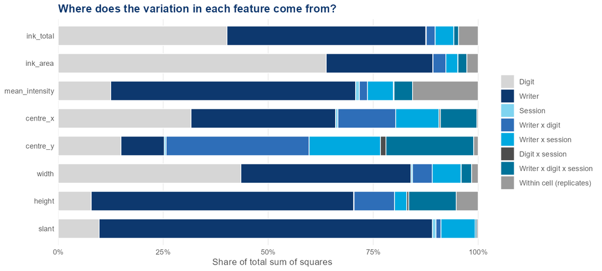

Figure 12: Share of feature variance for all eight ANOVA components.

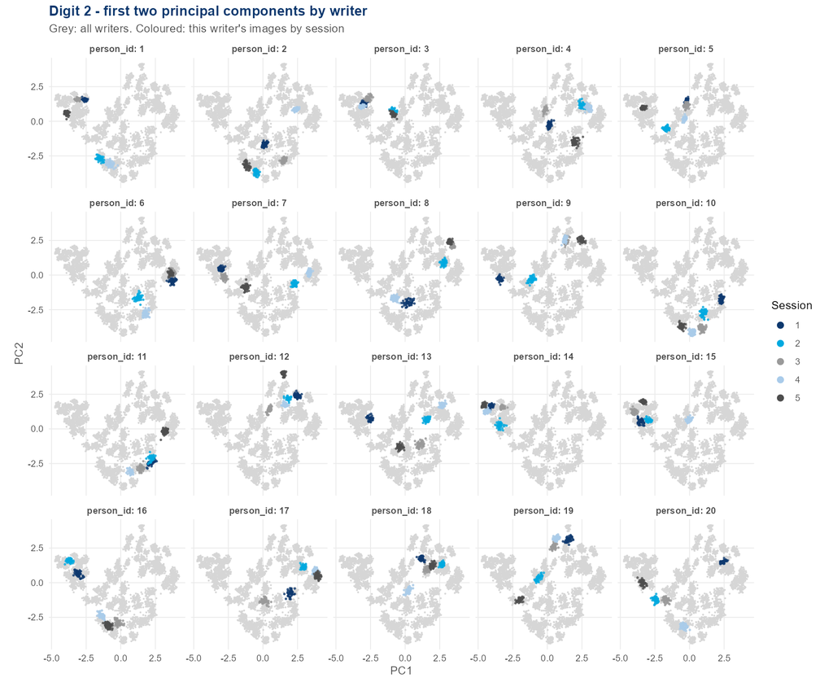

Figure 13: First two principal components of digit 2 by writer, coloured by session.

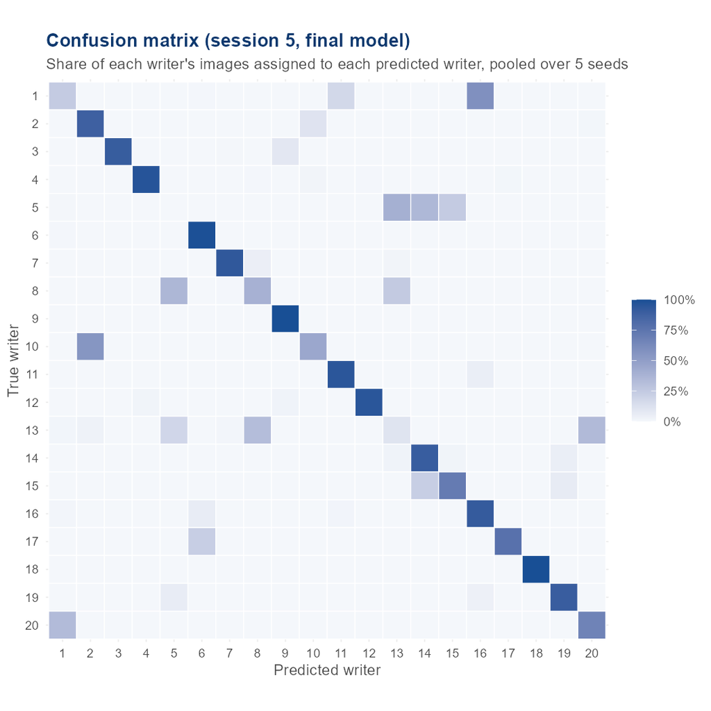

Figure 14: Confusion matrix of the final CNN on session 5, pooled over five seeds.

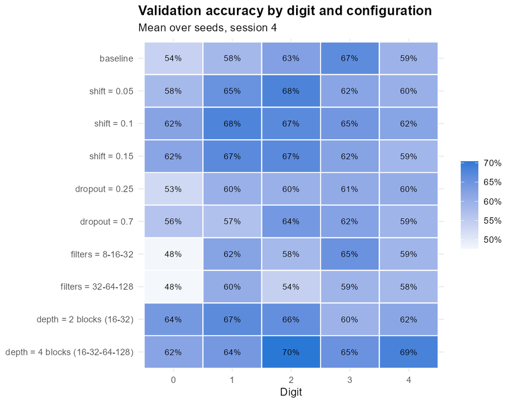

Figure 15: Validation accuracy by digit for each tuning configuration (session 4, mean over three seeds).

## Reproducing the results

Run the scripts in this order from the project root (each sources `R/setup.R`), then render this document:

1. `task_1/data_exploration.R`
2. `task_2/cnn_writer_id.R` and `task_2/learning_curves.R`
3. `task_5/cnn_tuning.R`
4. `task_2/cnn_final.R`
5. `task_3/siamese_network.R`